# Data types and missing data workbook

## Introduction

This is the workbook component of the "Data types and missing data" section of the tutorial.

# Relevant Resources

- [Data Types and Missing Data Reference](https://www.kaggle.com/residentmario/data-types-and-missing-data-reference)
- [Intro to Data Structures](https://pandas.pydata.org/pandas-docs/stable/dsintro.html) - http://archive.is/DP18t
- [Working with missing data](https://pandas.pydata.org/pandas-docs/stable/missing_data.html) - http://archive.is/QEHk9

# Set Up

Run the following cell to load your data and some utility functions

```python
import pandas as pd
import seaborn as sns
from learntools.advanced_pandas.data_types_missing_data import *

reviews = pd.read_csv("../input/wine-reviews/winemag-data-130k-v2.csv", index_col=0)
pd.set_option('max_rows', 5)
```

# Checking Answers

**Check your answers in each exercise using the `check_qN` function** (replacing `N` with the number of the exercise). For example here's how you would check an incorrect answer to exercise 1:

```python
check_q1(pd.DataFrame())
```

```
False
```

If you get stuck, **use the `answer_qN` function to see the code with the correct answer.**

For the first set of questions, running the `check_qN` on the correct answer returns `True`.

For the second set of questions, using this function to check a correct answer will present an informative graph!

```python
reviews.head()
```

|  | country | description | designation | points | price | province | region_1 | region_2 | taster_name | taster_twitter_handle | title | variety | winery |
| --- | --- | --- | --- | --- | --- | --- | --- | --- | --- | --- | --- | --- | --- |
| 0 | Italy | Aromas include tropical fruit, broom, brimston... | Vulkà Bianco | 87 | NaN | Sicily & Sardinia | Etna | NaN | Kerin O’Keefe | @kerinokeefe | Nicosia 2013 Vulkà Bianco (Etna) | White Blend | Nicosia |
| 1 | Portugal | This is ripe and fruity, a wine that is smooth... | Avidagos | 87 | 15.0 | Douro | NaN | NaN | Roger Voss | @vossroger | Quinta dos Avidagos 2011 Avidagos Red (Douro) | Portuguese Red | Quinta dos Avidagos |
| 2 | US | Tart and snappy, the flavors of lime flesh and... | NaN | 87 | 14.0 | Oregon | Willamette Valley | Willamette Valley | Paul Gregutt | @paulgwine | Rainstorm 2013 Pinot Gris (Willamette Valley) | Pinot Gris | Rainstorm |
| 3 | US | Pineapple rind, lemon pith and orange blossom ... | Reserve Late Harvest | 87 | 13.0 | Michigan | Lake Michigan Shore | NaN | Alexander Peartree | NaN | St. Julian 2013 Reserve Late Harvest Riesling ... | Riesling | St. Julian |
| 4 | US | Much like the regular bottling from 2012, this... | Vintner's Reserve Wild Child Block | 87 | 65.0 | Oregon | Willamette Valley | Willamette Valley | Paul Gregutt | @paulgwine | Sweet Cheeks 2012 Vintner's Reserve Wild Child... | Pinot Noir | Sweet Cheeks |

# Exercises

**Exercise 1**: What is the data type of the `points` column in the dataset?

```python
reviews.points.dtype
```

```
dtype('int64')
```

```python
print(check_q1(reviews.points.dtype))
print('-------')
print(answer_q1())
```

```
True
-------
reviews.points.dtype
None
```

**Exercise 2**: Create a `Series` from entries in the `price` column, but convert the entries to strings. Hint: strings are `str` in native Python.

```python
reviews.price.astype('str')
```

```
0          nan
1         15.0
          ...
129969    32.0
129970    21.0
Name: price, Length: 129971, dtype: object
```

```python
print(check_q2(reviews.price.astype('str')))
print('-------')
print(answer_q2())
```

```
True
-------
reviews.price.astype(str)
None
```

Here are a few visual exercises on missing data.

**Exercise 3**: Some wines do not list a price. How often does this occur? Generate a `Series`that, for each review in the dataset, states whether the wine reviewed has a null `price`.

```python
reviews.price.isnull()
```

```
0          True
1         False
          ...
129969    False
129970    False
Name: price, Length: 129971, dtype: bool
```

```
AxesSubplot(0.125,0.125;0.775x0.755)
-------
reviews.price.isnull()
None
```

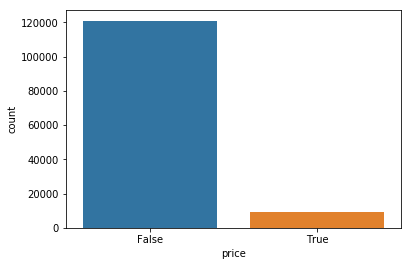

```python
print(check_q3(reviews.price.isnull()))
print('-------')
print(answer_q3())
```

**Exercise 4**: What are the most common wine-producing regions? Create a `Series` counting the number of times each value occurs in the `region_1` field. This field is often missing data, so replace missing values with `Unknown`. Sort in descending order. Your output should look something like this:

```
Unknown                    21247
Napa Valley                 4480
                           ...
Bardolino Superiore            1
Primitivo del Tarantino        1
Name: region_1, Length: 1230, dtype: int64
```

```python
reviews.region_1.fillna("Unknown").value_counts()
```

```
Unknown                  21247
Napa Valley               4480
                         ...
Australia-New Zealand        1
Texoma                       1
Name: region_1, Length: 1230, dtype: int64
```

```
AxesSubplot(0.125,0.125;0.775x0.755)
-------
reviews.region_1.fillna("Unknown").value_counts()
None
```

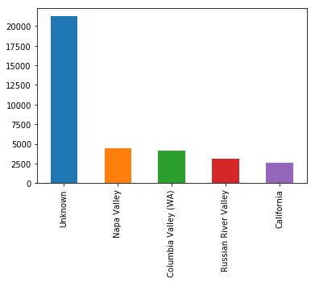

```python
print(check_q4(reviews.region_1.fillna("Unknown").value_counts()))
print('-------')
print(answer_q4())
```

**Exercise 5**: A neat property of boolean data types, like the ones created by the `isnull()` method, is that `False` gets treated as 0 and `True` as 1 when performing math on the values. Thus, the `sum()` of a list of boolean values will return how many times `True` appears in that list. Create a `pandas` `Series` showing how many times each of the columns in the dataset contains null values. Your result should look something like this:

```
country        63
description     0
               ..
variety         1
winery          0
Length: 13, dtype: int64
```

```python
reviews.isnull().sum()
```

```
country        63
description     0
               ..
variety         1
winery          0
Length: 13, dtype: int64
```

```
AxesSubplot(0.125,0.125;0.775x0.755)
-------
reviews.isnull().sum()
None
```

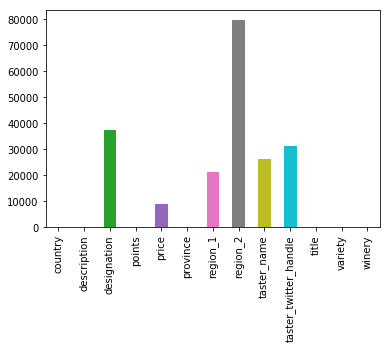

```python
print(check_q5(reviews.isnull().sum()))
print('-------')
print(answer_q5())
```

# Keep going

Move on to the [**Renaming and combining workbook**](https://www.kaggle.com/kernels/fork/598826)